# Raw IMC Data QC: Pixel Intensity Distributions

Tazein Shah

2026-05-26

## Overview

This notebook visualizes pixel-level ion count distributions from raw IMC TXT files — **before any steinbock preprocessing**. Each TXT file is one ROI; rows are pixels, columns are already labeled with both protein name and metal tag (e.g. `SMA(Pr141Di)`), so no external panel file is needed.

## 1. Load Libraries

```r
library(tidyverse)
library(ggridges)
```

## 2. Read All TXT Files and Combine

TXT files live in the raw data directory, one per ROI. Column names already contain the protein name and metal tag (e.g. `SMA(Pr141Di)`), so no renaming is needed. We drop acquisition metadata and non-biological channels, apply arcsinh transformation (cofactor = 1), and stack everything into a single long-format tibble.

```r
cofactor <- 1

txt_files <- list.files(
  path       = "/restricted/projectnb/camplab/projects/20220504_Suzuki_LN/Data/Imaging/IMC/Tumor/PardeeTumorAblations/Patient_14T/",
  pattern    = "\\.txt$",
  recursive  = TRUE,
  full.names = TRUE
)

# acquisition metadata and non-biological channels to drop
exclude_cols <- c("Start_push", "End_push", "Pushes_duration",
                  "X", "Y", "Z",
                  "DNA191(Ir191Di)", "DNA193(Ir193Di)", "Membrane(Pt196Di)")

raw_pixels <- map_dfr(txt_files, function(f) {
  df <- read_tsv(f, show_col_types = FALSE)

  df <- df %>% slice_sample(n = 50000)   # <-- add this

  df <- df %>% select(-any_of(exclude_cols))
  df <- df %>% mutate(across(where(is.numeric), ~asinh(. / cofactor)))

  fname      <- tools::file_path_sans_ext(basename(f))
  df$roi     <- fname
  df$patient <- str_extract(fname, "^[^_]+")
  df
})

cat("Total pixels loaded:", nrow(raw_pixels), "\n")
```

```
## Total pixels loaded: 200000
```

```r
cat("Patients found:", n_distinct(raw_pixels$patient), "\n")
```

```
## Patients found: 1
```

```r
cat("ROIs found:", n_distinct(raw_pixels$roi), "\n")
```

```
## ROIs found: 4
```

## 3. Pivot to Long Format

[output not shown]

[figure not shown]

```r
plot_long <- raw_pixels %>%
  pivot_longer(
    cols      = -c(roi, patient),
    names_to  = "marker",
    values_to = "intensity"
  )

single_roi <- unique(plot_long$roi)[1]
```

```r
ggsave("images/01_histogram_single_roi.png", plot = p, width = 14, height = 12, dpi = 150)
```

[output not shown]

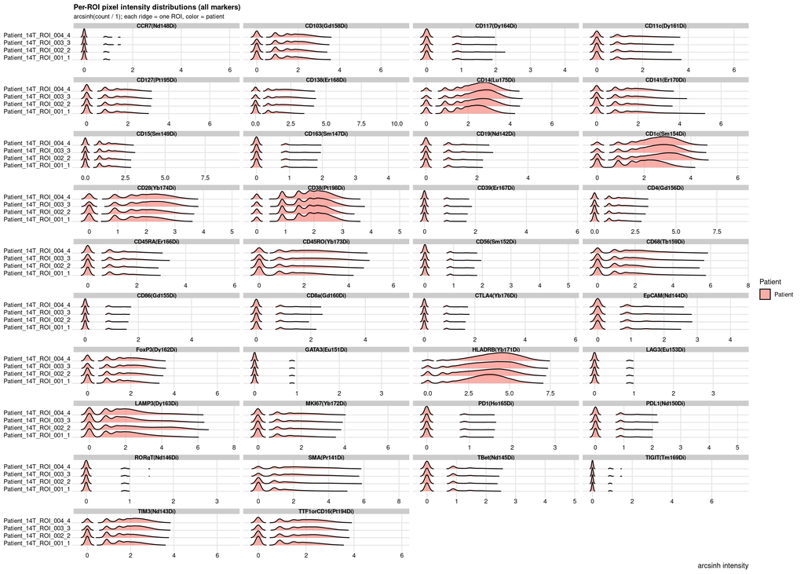

```r
p <- plot_long %>%
  ggplot(aes(x = intensity, y = roi, fill = patient)) +
  geom_density_ridges(alpha = 0.6, scale = 1.2, rel_min_height = 0.01) +
  facet_wrap(~marker, scales = "free_x", ncol = 4) +
  labs(
    title    = "Per-ROI pixel intensity distributions (all markers)",
    subtitle = "arcsinh(count / 1); each ridge = one ROI, color = patient",
    x        = "arcsinh intensity",
    y        = NULL,
    fill     = "Patient"
  ) +
  theme_ridges(font_size = 9) +
  theme(strip.text = element_text(face = "bold", size = 7))

p
```

```r
ggsave("images/02_ridgeplot_all_markers.png", plot = p, width = 14, height = 40, dpi = 150)
```

## 6. Density Overlay: All Channels for One ROI

An alternative view: all markers overlaid in a single density plot to compare the signal spread across channels. Useful for spotting channels with no signal or unusually high background.

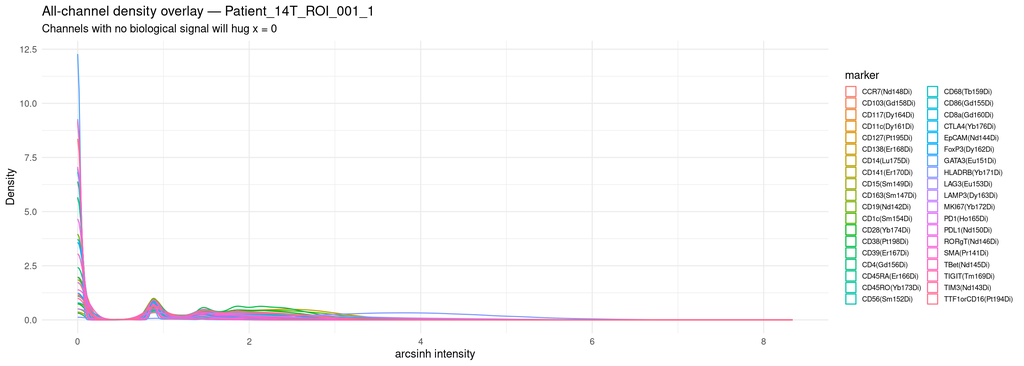

```r
p <- plot_long %>%
  filter(roi == single_roi) %>%
  ggplot(aes(x = intensity, color = marker)) +
  geom_density(linewidth = 0.5, alpha = 0.8) +
  labs(
    title    = paste0("All-channel density overlay — ", single_roi),
    subtitle = "Channels with no biological signal will hug x = 0",
    x        = "arcsinh intensity",
    y        = "Density"
  ) +
  theme_minimal(base_size = 11) +
  theme(legend.position = "right",
        legend.text     = element_text(size = 7),
        legend.key.size = unit(0.4, "cm"))

p
```

```r
ggsave("images/03_density_overlay.png", plot = p, width = 14, height = 5, dpi = 150)
```

## 7. Summary Table: Per-Channel Median and % Zero Pixels

A numeric summary to flag channels with very low signal (high % zero pixels) or unexpected medians — useful for early QC before committing to preprocessing.

```r
plot_long %>%
  group_by(marker) %>%
  summarise(
    median_intensity = round(median(intensity, na.rm = TRUE), 3),
    pct_zero         = round(mean(intensity == 0, na.rm = TRUE) * 100, 1),
    max_intensity    = round(max(intensity, na.rm = TRUE), 2),
    .groups = "drop"
  ) %>%
  arrange(desc(pct_zero)) %>%
  knitr::kable(caption = "Per-channel pixel intensity summary (arcsinh-transformed)")
```

Per-channel pixel intensity summary (arcsinh-transformed)

| marker | median_intensity | pct_zero | max_intensity |
| --- | --- | --- | --- |
| GATA3(Eu151Di) | 0.000 | 91.5 | 3.39 |
| LAG3(Eu153Di) | 0.000 | 87.7 | 3.60 |
| TIGIT(Tm169Di) | 0.000 | 86.8 | 7.35 |
| RORgT(Nd146Di) | 0.000 | 86.6 | 3.23 |
| CCR7(Nd148Di) | 0.000 | 85.1 | 5.97 |
| PD1(Ho165Di) | 0.000 | 81.4 | 3.24 |
| CD86(Gd155Di) | 0.000 | 79.4 | 5.38 |
| CTLA4(Yb176Di) | 0.000 | 78.1 | 5.68 |
| CD39(Er167Di) | 0.000 | 77.6 | 5.61 |
| CD163(Sm147Di) | 0.000 | 75.2 | 4.24 |
| CD56(Sm152Di) | 0.000 | 74.7 | 4.95 |
| CD117(Dy164Di) | 0.000 | 74.2 | 4.01 |
| CD8a(Gd160Di) | 0.000 | 66.6 | 5.14 |
| PDL1(Nd150Di) | 0.000 | 66.5 | 4.94 |
| EpCAM(Nd144Di) | 0.000 | 58.4 | 4.09 |
| CD19(Nd142Di) | 0.000 | 58.0 | 5.49 |
| TBet(Nd145Di) | 0.000 | 56.5 | 4.67 |
| CD11c(Dy161Di) | 0.881 | 46.5 | 6.02 |
| CD4(Gd156Di) | 0.881 | 43.6 | 8.72 |
| CD45RA(Er166Di) | 0.881 | 40.2 | 5.63 |
| MKI67(Yb172Di) | 0.881 | 38.1 | 6.31 |
| CD15(Sm149Di) | 0.881 | 36.1 | 8.93 |
| CD127(Pt195Di) | 1.005 | 31.7 | 6.81 |
| CD138(Er168Di) | 1.444 | 28.7 | 10.03 |
| CD141(Er170Di) | 1.444 | 25.8 | 6.65 |
| SMA(Pr141Di) | 1.547 | 25.4 | 7.73 |
| CD45RO(Yb173Di) | 1.586 | 25.2 | 6.00 |
| CD68(Tb159Di) | 1.487 | 24.8 | 7.22 |
| CD103(Gd158Di) | 1.444 | 23.5 | 6.72 |
| FoxP3(Dy162Di) | 1.478 | 22.5 | 6.39 |
| TTF1orCD16(Pt194Di) | 1.622 | 20.8 | 5.69 |
| LAMP3(Dy163Di) | 1.896 | 16.9 | 7.44 |
| TIM3(Nd143Di) | 1.712 | 16.9 | 6.41 |
| CD28(Yb174Di) | 1.818 | 14.9 | 4.72 |
| CD1c(Sm154Di) | 2.443 | 8.2 | 5.84 |
| CD14(Lu175Di) | 2.422 | 6.5 | 6.65 |
| CD38(Pt198Di) | 1.921 | 6.1 | 4.86 |
| HLADRB(Yb171Di) | 3.835 | 3.8 | 8.34 |